# Assignment - Final Project

Abduvosid Malikov

## Introduction

This is the Final Project for `Web Scraping with R` course. As a source, I used [IMDb](https://www.imdb.com/) website. IMDb[^1] is an online database of information related to movies and ratings. I scraped the webpage of [Top 250 movies](https://www.imdb.com/chart/top/). Code can be found [here](https://github.com/abdu95/web_scraping_R_final)

## Scrape the page

Here we can see the screenshot from the webpage.

[figure not shown]

In the webpage, we can see the **title** of the movie, its released **year**, its **rating**, and **link** to the movie. If we inspect the page, we also can see **cast** of the movie given in the movie title and **votes** given in the movie rating element.

Before continuing, I would ask the reader to read **Side note** section before getting familiar with the code.

I scraped the webpage and built a dataframe that contains such variables as ‘movie_title’, ‘year’, ‘rating’, ‘votes’, ‘cast’, ‘link’.

Dataframe

| movie_title | year | rating | votes | cast | link |
| --- | --- | --- | --- | --- | --- |
| A remény rabjai | 1994 | 9.2 | 2317238 | Frank Darabont (dir.), Tim Robbins, Morgan Freeman | https://www.imdb.com/title/tt0111161/ |
| A keresztapa | 1972 | 9.1 | 1600094 | Francis Ford Coppola (dir.), Marlon Brando, Al Pacino | https://www.imdb.com/title/tt0068646/ |
| A keresztapa II | 1974 | 9.0 | 1117623 | Francis Ford Coppola (dir.), Al Pacino, Robert De Niro | https://www.imdb.com/title/tt0071562/ |
| A sötét lovag | 2008 | 9.0 | 2279507 | Christopher Nolan (dir.), Christian Bale, Heath Ledger | https://www.imdb.com/title/tt0468569/ |

## First EDA: years

This statistics shows that the oldest movie (min) is taken in 1921, and youngest is in 2020 (max). In this list, movies that are released in 84 different years are given.

Summary statistics for years movie released

| Var1 | Freq |
| --- | --- |
| Min. | 1921.000 |
| 1st Qu. | 1968.750 |
| Median | 1994.500 |
| Mean | 1987.164 |
| 3rd Qu. | 2007.000 |
| Max. | 2020.000 |

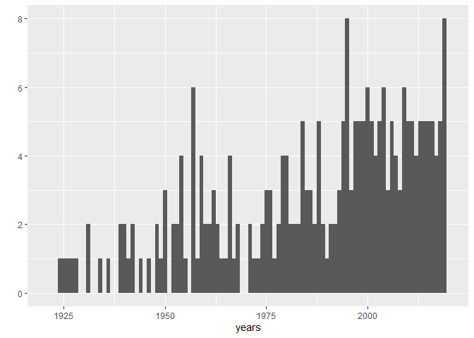

## Second EDA: ratings

Summary statistics of ratings

| Var1 | Freq |
| --- | --- |
| Min. | 8.0000 |
| 1st Qu. | 8.1000 |
| Median | 8.2000 |
| Mean | 8.2552 |
| 3rd Qu. | 8.4000 |
| Max. | 9.2000 |

The minimum rating that is given to movie is 8.0 and the maximum rating that is given to movie is 9.2

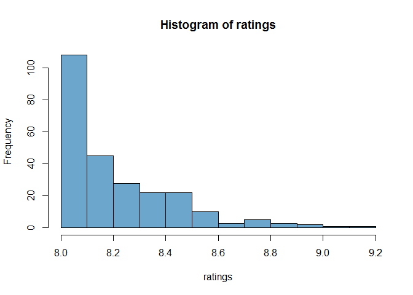

Histogram of ratings has long right tail. Most of the (more than 100) movies got rating between 8.0 and 8.1. Few number of movies got rating between 8.6 and 9.2

# Third EDA: votes

Summary statistics of votes

| Var1 | Freq |
| --- | --- |
| Min. | 25221.0 |
| 1st Qu. | 156800.8 |
| Median | 392691.5 |
| Mean | 536538.5 |
| 3rd Qu. | 804231.5 |
| Max. | 2317238.0 |

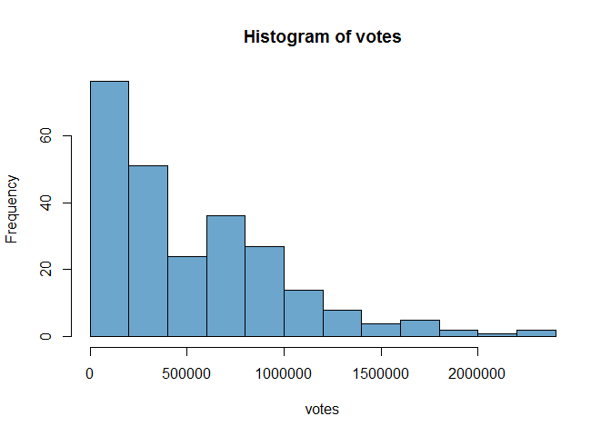

Histogram of votes is also skewed to right. Most of the movies obtained votes between 0 and 500000. Only few number of movies obtained more than one and half million votes

## Budget analysis

As a next step, I analyzed the budget and revenue of the movies. Below, the extraction from the dataframe is shown.

Dataframe

| movie_title | genre | revenue | budget |
| --- | --- | --- | --- |
| The Shawshank Redemption | Drama | 28815291 | 2.50e+07 |
| The Godfather | Crime,Drama | 246120986 | 6.00e+06 |
| The Godfather: Part II | Crime,Drama | 48035783 | 1.30e+07 |
| The Dark Knight | Action,Crime,Drama,Thriller | 1005082390 | 1.85e+08 |

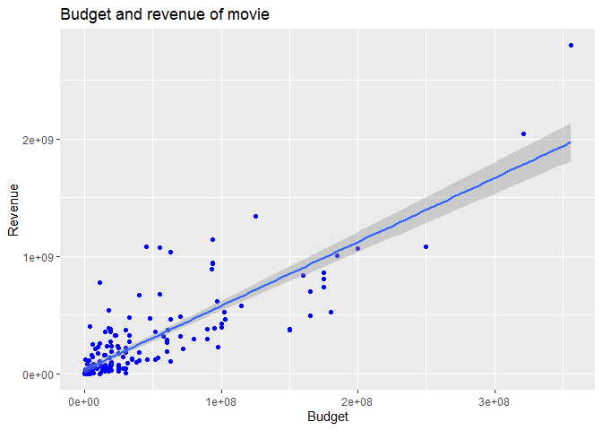

This plot shows the movies with the highest revenue. **Avengers: Endgame**, **Avengers: Infinity War** and **Harry Potter and the Deathly Hallows: Part 2** are the top “Movies with highest revenue”

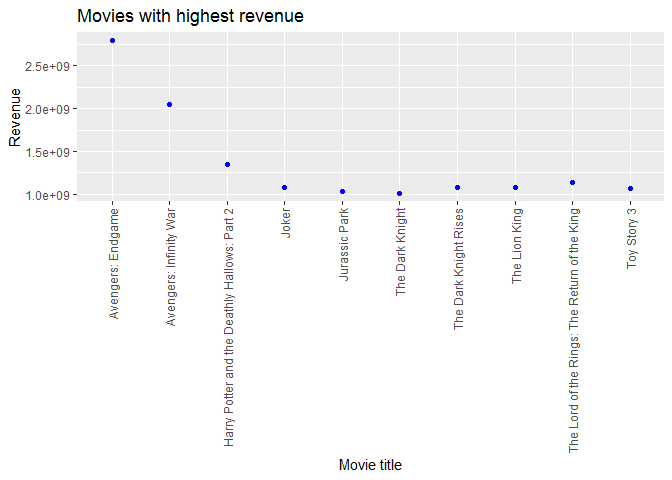

## Summary

In this assignment I scraped the webpage of Top 250 movies in IMDb and tried to analyze them. During the process, I faced several challenges. I had to understand the hierarchy of the webpage in order to extract the necessary element from it. The data was in text format and I had to clean it, extract number from it and convert it to suitable format. However, I am glad that I gained sufficient amount of knowledge throughout the process including extracting data from web, working with functions, building a dataframe from the obtained data.

By analyzing this data, I found out that movies with highest revenue does not necessarily achieve highest rating in this website. This means for users, how much money directors spend for the movie is not the number one factor to determine its quality. The movies with deep philosophical meaning and best acting have been more appreciated by the users, as it is the case for the top rated movie **The Shawshank Redemption**.

## Side note:

It takes 1.5 seconds to obtain data from one webpage. Since the code is obtaining data from 250 webpages, it took 7-8 minutes to compile the code fully and achieve the result. Therefore, if you want to execute R code or compile R markdown, I would ask you to be patient and wait 7-8 minutes to see the end result.

[^1]: Internet Movie Database